# Risk Factor Analysis

## Outcome Variable

**Outcome Variable:** ever_swasted

## Predictor Variables

**Intervention Variable:** parity

**Adjustment Set:**

- arm
- W_mage
- meducyrs
- feducyrs
- hhwealth_quart
- W_mhtcm
- W_mwtkg
- W_mbmi
- vagbrth
- W_nrooms
- impsan
- delta_W_mage
- delta_meducyrs
- delta_feducyrs
- delta_hhwealth_quart
- delta_W_mhtcm
- delta_W_mwtkg
- delta_W_mbmi
- delta_vagbrth
- delta_W_nrooms
- delta_impsan

## Stratifying Variables

The analysis was stratified on these variable(s):

- agecat
- studyid
- country

## Data Summary

| agecat | studyid | country | parity | ever_swasted | n_cell | n |
| --- | --- | --- | --- | --- | --- | --- |
| 0-24 months | ki1000304b-SAS-CompFeed | INDIA | 1 | 0 | 400 | 1513 |
| 0-24 months | ki1000304b-SAS-CompFeed | INDIA | 1 | 1 | 48 | 1513 |
| 0-24 months | ki1000304b-SAS-CompFeed | INDIA | 2 | 0 | 300 | 1513 |
| 0-24 months | ki1000304b-SAS-CompFeed | INDIA | 2 | 1 | 54 | 1513 |
| 0-24 months | ki1000304b-SAS-CompFeed | INDIA | 3+ | 0 | 590 | 1513 |
| 0-24 months | ki1000304b-SAS-CompFeed | INDIA | 3+ | 1 | 121 | 1513 |
| 0-24 months | ki1000304b-SAS-FoodSuppl | INDIA | 1 | 0 | 17 | 418 |
| 0-24 months | ki1000304b-SAS-FoodSuppl | INDIA | 1 | 1 | 4 | 418 |
| 0-24 months | ki1000304b-SAS-FoodSuppl | INDIA | 2 | 0 | 70 | 418 |
| 0-24 months | ki1000304b-SAS-FoodSuppl | INDIA | 2 | 1 | 7 | 418 |
| 0-24 months | ki1000304b-SAS-FoodSuppl | INDIA | 3+ | 0 | 260 | 418 |
| 0-24 months | ki1000304b-SAS-FoodSuppl | INDIA | 3+ | 1 | 60 | 418 |
| 0-24 months | ki1017093b-PROVIDE | BANGLADESH | 1 | 0 | 252 | 700 |
| 0-24 months | ki1017093b-PROVIDE | BANGLADESH | 1 | 1 | 19 | 700 |
| 0-24 months | ki1017093b-PROVIDE | BANGLADESH | 2 | 0 | 236 | 700 |
| 0-24 months | ki1017093b-PROVIDE | BANGLADESH | 2 | 1 | 8 | 700 |
| 0-24 months | ki1017093b-PROVIDE | BANGLADESH | 3+ | 0 | 170 | 700 |
| 0-24 months | ki1017093b-PROVIDE | BANGLADESH | 3+ | 1 | 15 | 700 |
| 0-24 months | ki1066203-TanzaniaChild2 | TANZANIA, UNITED REPUBLIC OF | 1 | 0 | 767 | 2357 |
| 0-24 months | ki1066203-TanzaniaChild2 | TANZANIA, UNITED REPUBLIC OF | 1 | 1 | 54 | 2357 |
| 0-24 months | ki1066203-TanzaniaChild2 | TANZANIA, UNITED REPUBLIC OF | 2 | 0 | 717 | 2357 |
| 0-24 months | ki1066203-TanzaniaChild2 | TANZANIA, UNITED REPUBLIC OF | 2 | 1 | 54 | 2357 |
| 0-24 months | ki1066203-TanzaniaChild2 | TANZANIA, UNITED REPUBLIC OF | 3+ | 0 | 716 | 2357 |
| 0-24 months | ki1066203-TanzaniaChild2 | TANZANIA, UNITED REPUBLIC OF | 3+ | 1 | 49 | 2357 |
| 0-24 months | ki1101329-Keneba | GAMBIA | 1 | 0 | 195 | 1990 |
| 0-24 months | ki1101329-Keneba | GAMBIA | 1 | 1 | 45 | 1990 |
| 0-24 months | ki1101329-Keneba | GAMBIA | 2 | 0 | 175 | 1990 |
| 0-24 months | ki1101329-Keneba | GAMBIA | 2 | 1 | 39 | 1990 |
| 0-24 months | ki1101329-Keneba | GAMBIA | 3+ | 0 | 1222 | 1990 |
| 0-24 months | ki1101329-Keneba | GAMBIA | 3+ | 1 | 314 | 1990 |

[output cut: 168 more lines]

The following strata were considered:

- agecat: 0-24 months, studyid: ki1000304b-SAS-CompFeed, country: INDIA
- agecat: 0-24 months, studyid: ki1000304b-SAS-FoodSuppl, country: INDIA
- agecat: 0-24 months, studyid: ki1017093b-PROVIDE, country: BANGLADESH
- agecat: 0-24 months, studyid: ki1066203-TanzaniaChild2, country: TANZANIA, UNITED REPUBLIC OF
- agecat: 0-24 months, studyid: ki1101329-Keneba, country: GAMBIA
- agecat: 0-24 months, studyid: ki1113344-GMS-Nepal, country: NEPAL
- agecat: 0-24 months, studyid: ki1126311-ZVITAMBO, country: ZIMBABWE
- agecat: 0-24 months, studyid: ki1135781-COHORTS, country: GUATEMALA
- agecat: 0-24 months, studyid: ki1135781-COHORTS, country: INDIA
- agecat: 0-24 months, studyid: ki1135781-COHORTS, country: PHILIPPINES
- agecat: 0-24 months, studyid: kiGH5241-JiVitA-3, country: BANGLADESH
- agecat: 0-6 months, studyid: ki1000304b-SAS-CompFeed, country: INDIA
- agecat: 0-6 months, studyid: ki1000304b-SAS-FoodSuppl, country: INDIA
- agecat: 0-6 months, studyid: ki1017093b-PROVIDE, country: BANGLADESH
- agecat: 0-6 months, studyid: ki1066203-TanzaniaChild2, country: TANZANIA, UNITED REPUBLIC OF
- agecat: 0-6 months, studyid: ki1101329-Keneba, country: GAMBIA
- agecat: 0-6 months, studyid: ki1113344-GMS-Nepal, country: NEPAL
- agecat: 0-6 months, studyid: ki1126311-ZVITAMBO, country: ZIMBABWE
- agecat: 0-6 months, studyid: ki1135781-COHORTS, country: GUATEMALA
- agecat: 0-6 months, studyid: ki1135781-COHORTS, country: INDIA
- agecat: 0-6 months, studyid: ki1135781-COHORTS, country: PHILIPPINES
- agecat: 0-6 months, studyid: kiGH5241-JiVitA-3, country: BANGLADESH
- agecat: 6-24 months, studyid: ki1000304b-SAS-CompFeed, country: INDIA
- agecat: 6-24 months, studyid: ki1000304b-SAS-FoodSuppl, country: INDIA
- agecat: 6-24 months, studyid: ki1017093b-PROVIDE, country: BANGLADESH
- agecat: 6-24 months, studyid: ki1066203-TanzaniaChild2, country: TANZANIA, UNITED REPUBLIC OF
- agecat: 6-24 months, studyid: ki1101329-Keneba, country: GAMBIA
- agecat: 6-24 months, studyid: ki1113344-GMS-Nepal, country: NEPAL
- agecat: 6-24 months, studyid: ki1126311-ZVITAMBO, country: ZIMBABWE
- agecat: 6-24 months, studyid: ki1135781-COHORTS, country: GUATEMALA
- agecat: 6-24 months, studyid: ki1135781-COHORTS, country: INDIA
- agecat: 6-24 months, studyid: ki1135781-COHORTS, country: PHILIPPINES
- agecat: 6-24 months, studyid: kiGH5241-JiVitA-3, country: BANGLADESH

### Dropped Strata

Some strata were dropped due to rare outcomes:

- agecat: 0-24 months, studyid: ki1000304b-SAS-FoodSuppl, country: INDIA
- agecat: 0-6 months, studyid: ki1000304b-SAS-FoodSuppl, country: INDIA
- agecat: 0-6 months, studyid: ki1017093b-PROVIDE, country: BANGLADESH
- agecat: 6-24 months, studyid: ki1000304b-SAS-FoodSuppl, country: INDIA
- agecat: 6-24 months, studyid: ki1017093b-PROVIDE, country: BANGLADESH

## Methods Detail

We’re interested in the causal parameters $E[Y_a]$ for all values of $a \in \mathcal{A}$. These parameters represent the mean outcome if, possibly contrary to fact, we intervened to set all units to have $A=a$. Under the randomization and positivity assumptions, these are identified by the statistical parameters $\psi_a=E_W[E_{Y|A,W}(Y|A=a,W)]$. In addition, we’re interested in the mean of $Y$, $E[Y]$ under no intervention (the observed mean). We will estimate these parameters by using SuperLearner to fit the relevant likelihood factors – $E_{Y|A,W}(Y|A=a,W)$ and $p(A=a|W)$, and then updating our likelihood fit using a joint TMLE.

For unadjusted analyses ($W=\{\}$), initial likelihoods were estimated using Lrnr_glm to estimate the simple $E(Y|A)$ and Lrnr_mean to estimate $p(A)$. For adjusted analyses, a small library containing Lrnr_glmnet, Lrnr_xgboost, and Lrnr_mean was used.

Having estimated these parameters, we will then use the delta method to estimate relative risks and attributable risks relative to a prespecified baseline level of $A$.

# Results Detail

## Results Plots

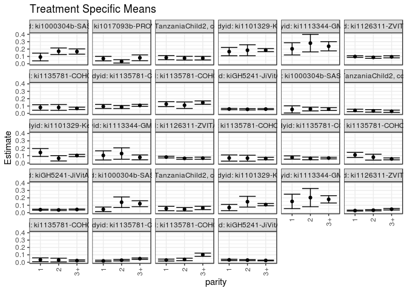

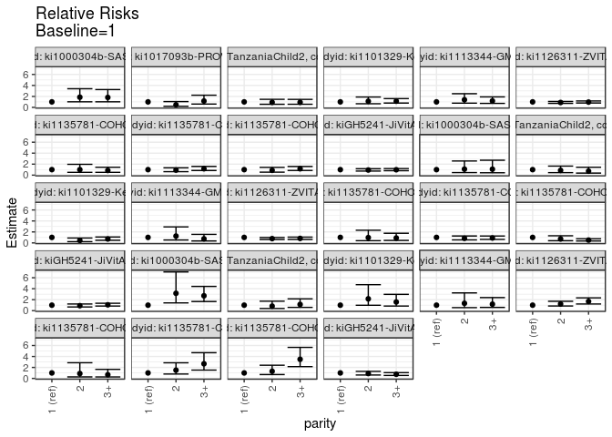

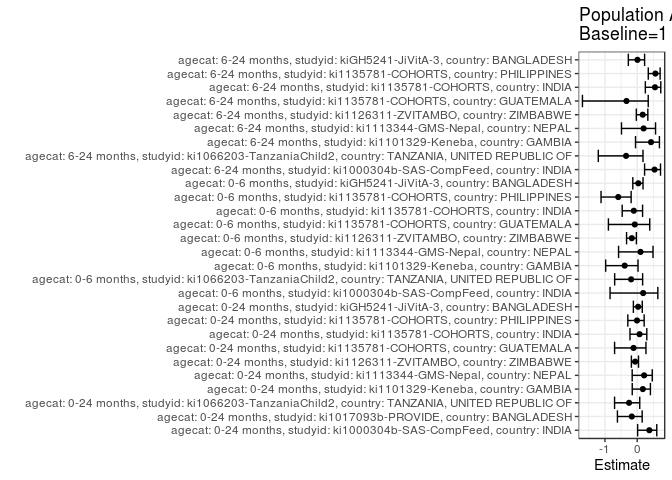

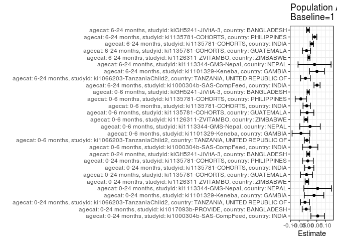

## Results Table

### Parameter: TSM

| agecat | studyid | country | intervention_level | baseline_level | estimate | ci_lower | ci_upper |
| --- | --- | --- | --- | --- | --- | --- | --- |
| 0-24 months | ki1000304b-SAS-CompFeed | INDIA | 1 | NA | 0.0919029 | 0.0392888 | 0.1445171 |
| 0-24 months | ki1000304b-SAS-CompFeed | INDIA | 2 | NA | 0.1701220 | 0.1256364 | 0.2146077 |
| 0-24 months | ki1000304b-SAS-CompFeed | INDIA | 3+ | NA | 0.1663651 | 0.1305223 | 0.2022079 |
| 0-24 months | ki1017093b-PROVIDE | BANGLADESH | 1 | NA | 0.0701107 | 0.0396891 | 0.1005323 |
| 0-24 months | ki1017093b-PROVIDE | BANGLADESH | 2 | NA | 0.0327869 | 0.0104267 | 0.0551470 |
| 0-24 months | ki1017093b-PROVIDE | BANGLADESH | 3+ | NA | 0.0810811 | 0.0417196 | 0.1204425 |
| 0-24 months | ki1066203-TanzaniaChild2 | TANZANIA, UNITED REPUBLIC OF | 1 | NA | 0.0834297 | 0.0552480 | 0.1116115 |
| 0-24 months | ki1066203-TanzaniaChild2 | TANZANIA, UNITED REPUBLIC OF | 2 | NA | 0.0760421 | 0.0503432 | 0.1017410 |
| 0-24 months | ki1066203-TanzaniaChild2 | TANZANIA, UNITED REPUBLIC OF | 3+ | NA | 0.0761561 | 0.0516772 | 0.1006350 |
| 0-24 months | ki1101329-Keneba | GAMBIA | 1 | NA | 0.1651930 | 0.1092985 | 0.2210876 |
| 0-24 months | ki1101329-Keneba | GAMBIA | 2 | NA | 0.1837604 | 0.1094466 | 0.2580742 |
| 0-24 months | ki1101329-Keneba | GAMBIA | 3+ | NA | 0.1851874 | 0.1643360 | 0.2060389 |
| 0-24 months | ki1113344-GMS-Nepal | NEPAL | 1 | NA | 0.2027793 | 0.1199189 | 0.2856396 |
| 0-24 months | ki1113344-GMS-Nepal | NEPAL | 2 | NA | 0.2802809 | 0.1615957 | 0.3989662 |
| 0-24 months | ki1113344-GMS-Nepal | NEPAL | 3+ | NA | 0.2379303 | 0.1754803 | 0.3003803 |
| 0-24 months | ki1126311-ZVITAMBO | ZIMBABWE | 1 | NA | 0.0981725 | 0.0868996 | 0.1094454 |
| 0-24 months | ki1126311-ZVITAMBO | ZIMBABWE | 2 | NA | 0.0870505 | 0.0731874 | 0.1009135 |
| 0-24 months | ki1126311-ZVITAMBO | ZIMBABWE | 3+ | NA | 0.0946117 | 0.0803988 | 0.1088246 |
| 0-24 months | ki1135781-COHORTS | GUATEMALA | 1 | NA | 0.0805609 | 0.0430276 | 0.1180943 |
| 0-24 months | ki1135781-COHORTS | GUATEMALA | 2 | NA | 0.0806699 | 0.0412936 | 0.1200462 |
| 0-24 months | ki1135781-COHORTS | GUATEMALA | 3+ | NA | 0.0685935 | 0.0524613 | 0.0847257 |
| 0-24 months | ki1135781-COHORTS | INDIA | 1 | NA | 0.0940831 | 0.0668758 | 0.1212903 |
| 0-24 months | ki1135781-COHORTS | INDIA | 2 | NA | 0.0862310 | 0.0657504 | 0.1067117 |
| 0-24 months | ki1135781-COHORTS | INDIA | 3+ | NA | 0.1089332 | 0.0954400 | 0.1224263 |
| 0-24 months | ki1135781-COHORTS | PHILIPPINES | 1 | NA | 0.1262723 | 0.0929339 | 0.1596106 |
| 0-24 months | ki1135781-COHORTS | PHILIPPINES | 2 | NA | 0.1109127 | 0.0668496 | 0.1549758 |
| 0-24 months | ki1135781-COHORTS | PHILIPPINES | 3+ | NA | 0.1462646 | 0.1232364 | 0.1692927 |
| 0-24 months | kiGH5241-JiVitA-3 | BANGLADESH | 1 | NA | 0.0592767 | 0.0503641 | 0.0681893 |
| 0-24 months | kiGH5241-JiVitA-3 | BANGLADESH | 2 | NA | 0.0552513 | 0.0461740 | 0.0643286 |
| 0-24 months | kiGH5241-JiVitA-3 | BANGLADESH | 3+ | NA | 0.0581770 | 0.0504692 | 0.0658849 |

[output cut: 54 more lines]

### Parameter: E(Y)

| agecat | studyid | country | intervention_level | baseline_level | estimate | ci_lower | ci_upper |
| --- | --- | --- | --- | --- | --- | --- | --- |
| 0-24 months | ki1000304b-SAS-CompFeed | INDIA | NA | NA | 0.1473893 | 0.1184132 | 0.1763654 |
| 0-24 months | ki1017093b-PROVIDE | BANGLADESH | NA | NA | 0.0600000 | 0.0423945 | 0.0776055 |
| 0-24 months | ki1066203-TanzaniaChild2 | TANZANIA, UNITED REPUBLIC OF | NA | NA | 0.0666101 | 0.0565417 | 0.0766785 |
| 0-24 months | ki1101329-Keneba | GAMBIA | NA | NA | 0.2000000 | 0.1824211 | 0.2175789 |
| 0-24 months | ki1113344-GMS-Nepal | NEPAL | NA | NA | 0.2580175 | 0.2252514 | 0.2907836 |
| 0-24 months | ki1126311-ZVITAMBO | ZIMBABWE | NA | NA | 0.0922194 | 0.0874171 | 0.0970218 |
| 0-24 months | ki1135781-COHORTS | GUATEMALA | NA | NA | 0.0723341 | 0.0584645 | 0.0862036 |
| 0-24 months | ki1135781-COHORTS | INDIA | NA | NA | 0.1014273 | 0.0927249 | 0.1101298 |
| 0-24 months | ki1135781-COHORTS | PHILIPPINES | NA | NA | 0.1254516 | 0.1136848 | 0.1372183 |
| 0-24 months | kiGH5241-JiVitA-3 | BANGLADESH | NA | NA | 0.0610254 | 0.0575469 | 0.0645038 |
| 0-6 months | ki1000304b-SAS-CompFeed | INDIA | NA | NA | 0.0664452 | 0.0425975 | 0.0902929 |
| 0-6 months | ki1066203-TanzaniaChild2 | TANZANIA, UNITED REPUBLIC OF | NA | NA | 0.0335172 | 0.0262496 | 0.0407848 |
| 0-6 months | ki1101329-Keneba | GAMBIA | NA | NA | 0.1026472 | 0.0888174 | 0.1164771 |
| 0-6 months | ki1113344-GMS-Nepal | NEPAL | NA | NA | 0.1151603 | 0.0912555 | 0.1390652 |
| 0-6 months | ki1126311-ZVITAMBO | ZIMBABWE | NA | NA | 0.0687987 | 0.0645835 | 0.0730139 |
| 0-6 months | ki1135781-COHORTS | GUATEMALA | NA | NA | 0.0630292 | 0.0484135 | 0.0776449 |
| 0-6 months | ki1135781-COHORTS | INDIA | NA | NA | 0.0675068 | 0.0601293 | 0.0748842 |
| 0-6 months | ki1135781-COHORTS | PHILIPPINES | NA | NA | 0.0693167 | 0.0602923 | 0.0783411 |
| 0-6 months | kiGH5241-JiVitA-3 | BANGLADESH | NA | NA | 0.0413642 | 0.0383846 | 0.0443438 |
| 6-24 months | ki1000304b-SAS-CompFeed | INDIA | NA | NA | 0.0964723 | 0.0729872 | 0.1199573 |
| 6-24 months | ki1066203-TanzaniaChild2 | TANZANIA, UNITED REPUBLIC OF | NA | NA | 0.0412682 | 0.0325201 | 0.0500164 |
| 6-24 months | ki1101329-Keneba | GAMBIA | NA | NA | 0.1200624 | 0.1055350 | 0.1345898 |
| 6-24 months | ki1113344-GMS-Nepal | NEPAL | NA | NA | 0.1898305 | 0.1581595 | 0.2215015 |
| 6-24 months | ki1126311-ZVITAMBO | ZIMBABWE | NA | NA | 0.0329203 | 0.0295572 | 0.0362834 |
| 6-24 months | ki1135781-COHORTS | GUATEMALA | NA | NA | 0.0247321 | 0.0159885 | 0.0334756 |
| 6-24 months | ki1135781-COHORTS | INDIA | NA | NA | 0.0403319 | 0.0344774 | 0.0461863 |
| 6-24 months | ki1135781-COHORTS | PHILIPPINES | NA | NA | 0.0669277 | 0.0576848 | 0.0761707 |
| 6-24 months | kiGH5241-JiVitA-3 | BANGLADESH | NA | NA | 0.0319690 | 0.0290813 | 0.0348568 |

### Parameter: RR

| agecat | studyid | country | intervention_level | baseline_level | estimate | ci_lower | ci_upper |
| --- | --- | --- | --- | --- | --- | --- | --- |
| 0-24 months | ki1000304b-SAS-CompFeed | INDIA | 1 | 1 | 1.0000000 | 1.0000000 | 1.0000000 |
| 0-24 months | ki1000304b-SAS-CompFeed | INDIA | 2 | 1 | 1.8511056 | 1.0092249 | 3.3952711 |
| 0-24 months | ki1000304b-SAS-CompFeed | INDIA | 3+ | 1 | 1.8102261 | 1.0084866 | 3.2493428 |
| 0-24 months | ki1017093b-PROVIDE | BANGLADESH | 1 | 1 | 1.0000000 | 1.0000000 | 1.0000000 |
| 0-24 months | ki1017093b-PROVIDE | BANGLADESH | 2 | 1 | 0.4676445 | 0.2083855 | 1.0494558 |
| 0-24 months | ki1017093b-PROVIDE | BANGLADESH | 3+ | 1 | 1.1564723 | 0.6030613 | 2.2177317 |
| 0-24 months | ki1066203-TanzaniaChild2 | TANZANIA, UNITED REPUBLIC OF | 1 | 1 | 1.0000000 | 1.0000000 | 1.0000000 |
| 0-24 months | ki1066203-TanzaniaChild2 | TANZANIA, UNITED REPUBLIC OF | 2 | 1 | 0.9114506 | 0.5657530 | 1.4683832 |
| 0-24 months | ki1066203-TanzaniaChild2 | TANZANIA, UNITED REPUBLIC OF | 3+ | 1 | 0.9128171 | 0.5725813 | 1.4552258 |
| 0-24 months | ki1101329-Keneba | GAMBIA | 1 | 1 | 1.0000000 | 1.0000000 | 1.0000000 |
| 0-24 months | ki1101329-Keneba | GAMBIA | 2 | 1 | 1.1123981 | 0.6563992 | 1.8851784 |
| 0-24 months | ki1101329-Keneba | GAMBIA | 3+ | 1 | 1.1210368 | 0.7848156 | 1.6012978 |
| 0-24 months | ki1113344-GMS-Nepal | NEPAL | 1 | 1 | 1.0000000 | 1.0000000 | 1.0000000 |
| 0-24 months | ki1113344-GMS-Nepal | NEPAL | 2 | 1 | 1.3821973 | 0.7672523 | 2.4900146 |
| 0-24 months | ki1113344-GMS-Nepal | NEPAL | 3+ | 1 | 1.1733463 | 0.7220900 | 1.9066063 |
| 0-24 months | ki1126311-ZVITAMBO | ZIMBABWE | 1 | 1 | 1.0000000 | 1.0000000 | 1.0000000 |
| 0-24 months | ki1126311-ZVITAMBO | ZIMBABWE | 2 | 1 | 0.8867096 | 0.7286423 | 1.0790671 |
| 0-24 months | ki1126311-ZVITAMBO | ZIMBABWE | 3+ | 1 | 0.9637297 | 0.7976730 | 1.1643554 |
| 0-24 months | ki1135781-COHORTS | GUATEMALA | 1 | 1 | 1.0000000 | 1.0000000 | 1.0000000 |
| 0-24 months | ki1135781-COHORTS | GUATEMALA | 2 | 1 | 1.0013522 | 0.5099281 | 1.9663678 |
| 0-24 months | ki1135781-COHORTS | GUATEMALA | 3+ | 1 | 0.8514489 | 0.5051914 | 1.4350310 |
| 0-24 months | ki1135781-COHORTS | INDIA | 1 | 1 | 1.0000000 | 1.0000000 | 1.0000000 |
| 0-24 months | ki1135781-COHORTS | INDIA | 2 | 1 | 0.9165415 | 0.6304811 | 1.3323924 |
| 0-24 months | ki1135781-COHORTS | INDIA | 3+ | 1 | 1.1578405 | 0.8452993 | 1.5859407 |
| 0-24 months | ki1135781-COHORTS | PHILIPPINES | 1 | 1 | 1.0000000 | 1.0000000 | 1.0000000 |
| 0-24 months | ki1135781-COHORTS | PHILIPPINES | 2 | 1 | 0.8783616 | 0.5451484 | 1.4152460 |
| 0-24 months | ki1135781-COHORTS | PHILIPPINES | 3+ | 1 | 1.1583268 | 0.8519139 | 1.5749490 |
| 0-24 months | kiGH5241-JiVitA-3 | BANGLADESH | 1 | 1 | 1.0000000 | 1.0000000 | 1.0000000 |
| 0-24 months | kiGH5241-JiVitA-3 | BANGLADESH | 2 | 1 | 0.9320908 | 0.7436752 | 1.1682429 |
| 0-24 months | kiGH5241-JiVitA-3 | BANGLADESH | 3+ | 1 | 0.9814487 | 0.8048798 | 1.1967522 |

[output cut: 54 more lines]

### Parameter: PAR

| agecat | studyid | country | intervention_level | baseline_level | estimate | ci_lower | ci_upper |
| --- | --- | --- | --- | --- | --- | --- | --- |
| 0-24 months | ki1000304b-SAS-CompFeed | INDIA | 1 | NA | 0.0554864 | 0.0166856 | 0.0942871 |
| 0-24 months | ki1017093b-PROVIDE | BANGLADESH | 1 | NA | -0.0101107 | -0.0328889 | 0.0126675 |
| 0-24 months | ki1066203-TanzaniaChild2 | TANZANIA, UNITED REPUBLIC OF | 1 | NA | -0.0168196 | -0.0424571 | 0.0088179 |
| 0-24 months | ki1101329-Keneba | GAMBIA | 1 | NA | 0.0348070 | -0.0208188 | 0.0904328 |
| 0-24 months | ki1113344-GMS-Nepal | NEPAL | 1 | NA | 0.0552382 | -0.0232144 | 0.1336908 |
| 0-24 months | ki1126311-ZVITAMBO | ZIMBABWE | 1 | NA | -0.0059530 | -0.0160903 | 0.0041842 |
| 0-24 months | ki1135781-COHORTS | GUATEMALA | 1 | NA | -0.0082269 | -0.0424013 | 0.0259476 |
| 0-24 months | ki1135781-COHORTS | INDIA | 1 | NA | 0.0073443 | -0.0187553 | 0.0334439 |
| 0-24 months | ki1135781-COHORTS | PHILIPPINES | 1 | NA | -0.0008207 | -0.0322388 | 0.0305974 |
| 0-24 months | kiGH5241-JiVitA-3 | BANGLADESH | 1 | NA | 0.0017487 | -0.0066352 | 0.0101325 |
| 0-6 months | ki1000304b-SAS-CompFeed | INDIA | 1 | NA | 0.0122446 | -0.0320036 | 0.0564928 |
| 0-6 months | ki1066203-TanzaniaChild2 | TANZANIA, UNITED REPUBLIC OF | 1 | NA | -0.0063412 | -0.0206253 | 0.0079429 |
| 0-6 months | ki1101329-Keneba | GAMBIA | 1 | NA | -0.0398842 | -0.0905332 | 0.0107649 |
| 0-6 months | ki1113344-GMS-Nepal | NEPAL | 1 | NA | 0.0118726 | -0.0465080 | 0.0702531 |
| 0-6 months | ki1126311-ZVITAMBO | ZIMBABWE | 1 | NA | -0.0115680 | -0.0220292 | -0.0011068 |
| 0-6 months | ki1135781-COHORTS | GUATEMALA | 1 | NA | -0.0047936 | -0.0431518 | 0.0335647 |
| 0-6 months | ki1135781-COHORTS | INDIA | 1 | NA | -0.0071127 | -0.0281379 | 0.0139124 |
| 0-6 months | ki1135781-COHORTS | PHILIPPINES | 1 | NA | -0.0407347 | -0.0727675 | -0.0087020 |
| 0-6 months | kiGH5241-JiVitA-3 | BANGLADESH | 1 | NA | 0.0014232 | -0.0050953 | 0.0079418 |
| 6-24 months | ki1000304b-SAS-CompFeed | INDIA | 1 | NA | 0.0518191 | 0.0344136 | 0.0692245 |
| 6-24 months | ki1066203-TanzaniaChild2 | TANZANIA, UNITED REPUBLIC OF | 1 | NA | -0.0142574 | -0.0417821 | 0.0132673 |
| 6-24 months | ki1101329-Keneba | GAMBIA | 1 | NA | 0.0513134 | 0.0087152 | 0.0939117 |
| 6-24 months | ki1113344-GMS-Nepal | NEPAL | 1 | NA | 0.0376579 | -0.0565540 | 0.1318698 |
| 6-24 months | ki1126311-ZVITAMBO | ZIMBABWE | 1 | NA | 0.0055899 | -0.0002609 | 0.0114407 |
| 6-24 months | ki1135781-COHORTS | GUATEMALA | 1 | NA | -0.0082350 | -0.0316403 | 0.0151703 |
| 6-24 months | ki1135781-COHORTS | INDIA | 1 | NA | 0.0222114 | 0.0124137 | 0.0320091 |
| 6-24 months | ki1135781-COHORTS | PHILIPPINES | 1 | NA | 0.0377112 | 0.0247525 | 0.0506698 |
| 6-24 months | kiGH5241-JiVitA-3 | BANGLADESH | 1 | NA | 0.0002654 | -0.0077036 | 0.0082344 |

### Parameter: PAF

| agecat | studyid | country | intervention_level | baseline_level | estimate | ci_lower | ci_upper |
| --- | --- | --- | --- | --- | --- | --- | --- |
| 0-24 months | ki1000304b-SAS-CompFeed | INDIA | 1 | NA | 0.3764613 | 0.0127030 | 0.6061969 |
| 0-24 months | ki1017093b-PROVIDE | BANGLADESH | 1 | NA | -0.1685117 | -0.6132761 | 0.1536356 |
| 0-24 months | ki1066203-TanzaniaChild2 | TANZANIA, UNITED REPUBLIC OF | 1 | NA | -0.2525087 | -0.7020864 | 0.0783205 |
| 0-24 months | ki1101329-Keneba | GAMBIA | 1 | NA | 0.1740349 | -0.1541790 | 0.4089146 |
| 0-24 months | ki1113344-GMS-Nepal | NEPAL | 1 | NA | 0.2140872 | -0.1561356 | 0.4657556 |
| 0-24 months | ki1126311-ZVITAMBO | ZIMBABWE | 1 | NA | -0.0645530 | -0.1803629 | 0.0398943 |
| 0-24 months | ki1135781-COHORTS | GUATEMALA | 1 | NA | -0.1137342 | -0.7012693 | 0.2708951 |
| 0-24 months | ki1135781-COHORTS | INDIA | 1 | NA | 0.0724092 | -0.2239463 | 0.2970079 |
| 0-24 months | ki1135781-COHORTS | PHILIPPINES | 1 | NA | -0.0065422 | -0.2909074 | 0.2151822 |
| 0-24 months | kiGH5241-JiVitA-3 | BANGLADESH | 1 | NA | 0.0286549 | -0.1188340 | 0.1567012 |
| 0-6 months | ki1000304b-SAS-CompFeed | INDIA | 1 | NA | 0.1842812 | -0.8418999 | 0.6387442 |
| 0-6 months | ki1066203-TanzaniaChild2 | TANZANIA, UNITED REPUBLIC OF | 1 | NA | -0.1891923 | -0.6991795 | 0.1677287 |
| 0-6 months | ki1101329-Keneba | GAMBIA | 1 | NA | -0.3885559 | -0.9779446 | 0.0252066 |
| 0-6 months | ki1113344-GMS-Nepal | NEPAL | 1 | NA | 0.1030959 | -0.5777657 | 0.4901417 |
| 0-6 months | ki1126311-ZVITAMBO | ZIMBABWE | 1 | NA | -0.1681427 | -0.3303742 | -0.0256943 |
| 0-6 months | ki1135781-COHORTS | GUATEMALA | 1 | NA | -0.0760529 | -0.8929700 | 0.3883210 |
| 0-6 months | ki1135781-COHORTS | INDIA | 1 | NA | -0.1053633 | -0.4652743 | 0.1661439 |
| 0-6 months | ki1135781-COHORTS | PHILIPPINES | 1 | NA | -0.5876613 | -1.1209475 | -0.1884634 |
| 0-6 months | kiGH5241-JiVitA-3 | BANGLADESH | 1 | NA | 0.0344068 | -0.1365186 | 0.1796260 |
| 6-24 months | ki1000304b-SAS-CompFeed | INDIA | 1 | NA | 0.5371395 | 0.2285672 | 0.7222832 |
| 6-24 months | ki1066203-TanzaniaChild2 | TANZANIA, UNITED REPUBLIC OF | 1 | NA | -0.3454811 | -1.2059642 | 0.1793523 |
| 6-24 months | ki1101329-Keneba | GAMBIA | 1 | NA | 0.4273897 | -0.0521367 | 0.6883651 |
| 6-24 months | ki1113344-GMS-Nepal | NEPAL | 1 | NA | 0.1983764 | -0.4874374 | 0.5679815 |
| 6-24 months | ki1126311-ZVITAMBO | ZIMBABWE | 1 | NA | 0.1698019 | -0.0273210 | 0.3291008 |
| 6-24 months | ki1135781-COHORTS | GUATEMALA | 1 | NA | -0.3329670 | -1.6972387 | 0.3412518 |
| 6-24 months | ki1135781-COHORTS | INDIA | 1 | NA | 0.5507168 | 0.2516589 | 0.7302628 |
| 6-24 months | ki1135781-COHORTS | PHILIPPINES | 1 | NA | 0.5634610 | 0.3429180 | 0.7099810 |
| 6-24 months | kiGH5241-JiVitA-3 | BANGLADESH | 1 | NA | 0.0083018 | -0.2751047 | 0.2287180 |